# Study Time and GPA Analysis in R

Pengtian Sun, Rachel Baron, Stavan Sagala, Xinyue Wang

# Load Data

```r
data <- read_csv("Student_performance_data.csv")
head(data)
```

```
## # A tibble: 6 × 15
##   StudentID   Age Gender Ethnicity ParentalEducation StudyTimeWeekly Absences
##       <dbl> <dbl>  <dbl>     <dbl>             <dbl>           <dbl>    <dbl>
## 1      1001    17      1         0                 2           19.8         7
## 2      1002    18      0         0                 1           15.4         0
## 3      1003    15      0         2                 3            4.21       26
## 4      1004    17      1         0                 3           10.0        14
## 5      1005    17      1         0                 2            4.67       17
## 6      1006    18      0         0                 1            8.19        0
## # ℹ 8 more variables: Tutoring <dbl>, ParentalSupport <dbl>,
## #   Extracurricular <dbl>, Sports <dbl>, Music <dbl>, Volunteering <dbl>,
## #   GPA <dbl>, GradeClass <dbl>
```

# Group Members

- Rachel Baron
- Pengtian Sun
- Stavan Sagala
- Xinyue Wang

# Introduction

As we know, high school academic performance can shape one’s future. How well you do in school determines everything from college admissions to job opportunities. While many factors contribute to academic performance, the amount of time spent studying is in the hands of the students themselves. Understanding whether the amount of time a student spent studying each week truly predicts their GPA is essential for designing effective academic success strategies and can help students decide how to best manage their workload.

With this in mind, we will be investigating the relationship between the amount of time high school students spend studying and their earned GPA. The main question we aim to answer is: “Is weekly study time correlated to GPA among high school students?”.

By using statistical analysis methods, we find strong evidence for a positive correlation between weekly study time and GPA among high school students, showing that good study habits contribute significantly to academic achievement. At the same time, we also show that study time alone does not explain much of the overall variation in GPA, so academic performance should be understood as a multi-factor outcome rather than the result of one single behavior.

# Background

## Data Sources

- Data name: Student Performance and Study Habits.
- Collector: Rabie El Kharoua.
- License: CC BY 4.0.
- Links: https://www.kaggle.com/datasets/rabieelkharoua/students-performance-dataset
- How the data was collected: This dataset is synthetic and was generated for educational purposes. It contains comprehensive information on 2,392 high school students, detailing their demographics, study habits, parental involvement, extracurricular activities, and academic performance. The target variable, GradeClass, classifies students’ grades into distinct categories, providing a robust dataset for educational research, predictive modeling, and statistical analysis.

## Variables

What each row represents: Each row represents one high school student, including their weekly study time, GPA, and other academic or demographic characteristics.

### Core variables used in the simple model

- `StudyTimeWeekly`: hours per week spent studying, continuous
- `GPA`: grade point average, continuous

### Additional variables added in the multiple regression model

- `Absences`: number of school absences
- `ParentalSupport`: a coded measure of parent support level
- `Tutoring`: whether the student receives tutoring support

## Describe background needed to understand the question：

Understanding the relationship between study behaviors and academic performance is an important research topic in education. Prior studies often examine whether the amount of time students spend studying is associated with improved grades, as study habits are commonly viewed as indicators of academic engagement and motivation. However, study time alone does not fully capture the quality or efficiency of learning. Some students may spend many hours studying but use ineffective strategies, while others may achieve high performance with fewer hours through better planning or understanding of the material.

Therefore, exploring whether weekly study time correlates with GPA helps us understand how strongly time investment alone predicts real academic outcomes. Since GPA summarizes overall performance across assignments, quizzes, exams, and class participation, analyzing this relationship can clarify whether simply “studying more” leads to better results, or whether the connection is weaker than expected.

## Describe unusual factors

There are no obvious unusual factors in our data, because all the students in this dataset have corresponding study time and GPA. However, there are some students who spend a considerable amount of time studying, but their GPA is surprisingly low. There are many reasons for this situation. For instance, they may spend too much time studying and be very sleepy during class, have low participation in class, use ineffective study strategies, or be in a poor exam state and fail to achieve good grades.

## Initial Visualization

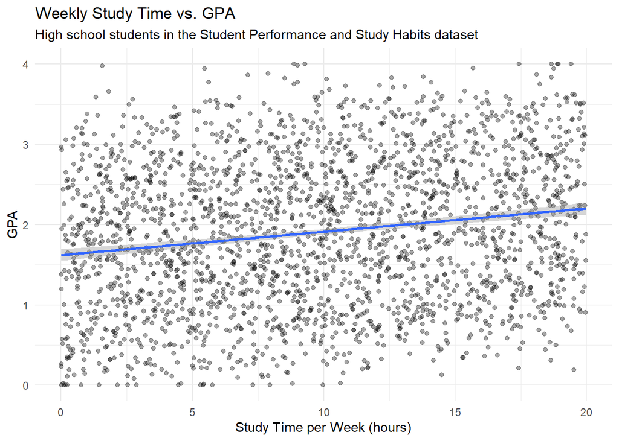

```r
ggplot(data, aes(x = StudyTimeWeekly, y = GPA)) +
  geom_point(alpha = 0.35) +
  geom_smooth(method = "lm", se = TRUE, linewidth = 1) +
  labs(
    title = "Weekly Study Time vs. GPA",
    subtitle = "High school students in the Student Performance and Study Habits dataset",
    x = "Study Time per Week (hours)",
    y = "GPA"
  ) +
  theme_minimal()
```

The scatterplot shows a weak positive association between weekly study time and GPA, suggesting that although students who study more tend to have slightly higher GPAs, the relationship is not strong and there is substantial variation in GPA for any given study time.

## Data Structure

- Rows: Each row in the dataset represents a single, unique high school student.
- Columns: There are 15 variables in total, recording demographic details (e.g., `Age`, `Gender`), academic behaviors (e.g., `StudyTimeWeekly`, `Absences`), and performance outcomes (e.g., `GPA`, `GradeClass`).
- Sample Size: The dataset contains a total of 2,392 students (`n = 2392`).

# Data Cleaning and Processing

To ensure the data was suitable for analysis, we performed several cleaning and validation steps. First, we checked the dataset for missing values and found none (0 missing entries), so no imputation was necessary. We also verified that there were no duplicate rows, ensuring that each student in the dataset is unique.

```r
missing_total <- sum(is.na(data))
duplicate_rows <- sum(duplicated(data))

missing_total
```

```
## [1] 0
```

```r
duplicate_rows
```

```
## [1] 0
```

```r
analysis_data <- data %>%
  select(StudyTimeWeekly, GPA, Absences, ParentalSupport, Tutoring) %>%
  mutate(
    Tutoring = factor(Tutoring, levels = c(0, 1), labels = c("No", "Yes")),
    ParentalSupport = factor(ParentalSupport, ordered = FALSE)
  )

summary(analysis_data)
```

```
##  StudyTimeWeekly          GPA           Absences     ParentalSupport Tutoring
##  Min.   : 0.001056   Min.   :0.000   Min.   : 0.00   0:212           No :1671
##  1st Qu.: 5.043079   1st Qu.:1.175   1st Qu.: 7.00   1:489           Yes: 721
##  Median : 9.705363   Median :1.893   Median :15.00   2:740
##  Mean   : 9.771992   Mean   :1.906   Mean   :14.54   3:697
##  3rd Qu.:14.408409   3rd Qu.:2.622   3rd Qu.:22.00   4:254
##  Max.   :19.978094   Max.   :4.000   Max.   :29.00
```

```r
head(analysis_data)
```

```
## # A tibble: 6 × 5
##   StudyTimeWeekly   GPA Absences ParentalSupport Tutoring
##             <dbl> <dbl>    <dbl> <fct>           <fct>
## 1           19.8  2.93         7 2               Yes
## 2           15.4  3.04         0 1               No
## 3            4.21 0.113       26 2               No
## 4           10.0  2.05        14 3               No
## 5            4.67 1.29        17 3               Yes
## 6            8.19 3.08         0 1               No
```

# Statistical Analysis

In this study, we investigate whether weekly study time is associated with high school students’ GPA. Our main goal is to test if there is a linear relationship between students’ average weekly study hours and their GPA.

We begin with a simple linear regression model because it directly answers our main question about study time and GPA. We then extend the analysis using a multiple regression model, adding `Absences`, `ParentalSupport`, and `Tutoring` to see whether the relationship between study time and GPA remains after accounting for other relevant academic and support-related factors.

## Parameter of Interest

Let:

- Xi = weekly study time (in hours) for the i-th student
- Yi = GPA (0–4 scale) for the i-th student

We model the population relationship with a simple linear regression: Yi=β0+β1Xi+εi

where:

- β0 = true intercept (expected GPA for a student who studies 0 hours per week)
- β1 = true slope, the expected change in GPA for each additional hour of study per week
- εi = random error term

Our primary parameter of interest is the slope `β1`. It tells us how strongly GPA is expected to change, on average, when weekly study time increases by one hour.

## Type of Inference

We use simple linear regression and a t-test on the slope to decide whether β1 is not 0. This allows us to test whether increased study time is associated with higher GPA in the population or it is associated with lower GPA in the population.

```r
cor(analysis_data$StudyTimeWeekly, analysis_data$GPA)
```

```
## [1] 0.1792751
```

## Simple Linear Regression

```r
simple_model <- lm(GPA ~ StudyTimeWeekly, data = analysis_data)
summary(simple_model)
```

```
##
## Call:
## lm(formula = GPA ~ StudyTimeWeekly, data = analysis_data)
##
## Residuals:
##      Min       1Q   Median       3Q      Max
## -1.99922 -0.73441 -0.00121  0.72442  2.31142
##
## Coefficients:
##                 Estimate Std. Error t value Pr(>|t|)
## (Intercept)     1.622567   0.036777  44.119   <2e-16 ***
## StudyTimeWeekly 0.029024   0.003258   8.909   <2e-16 ***
## ---
## Signif. codes:  0 '***' 0.001 '**' 0.01 '*' 0.05 '.' 0.1 ' ' 1
##
## Residual standard error: 0.9005 on 2390 degrees of freedom
## Multiple R-squared:  0.03214,    Adjusted R-squared:  0.03173
## F-statistic: 79.36 on 1 and 2390 DF,  p-value: < 2.2e-16
```

## Checking Assumptions

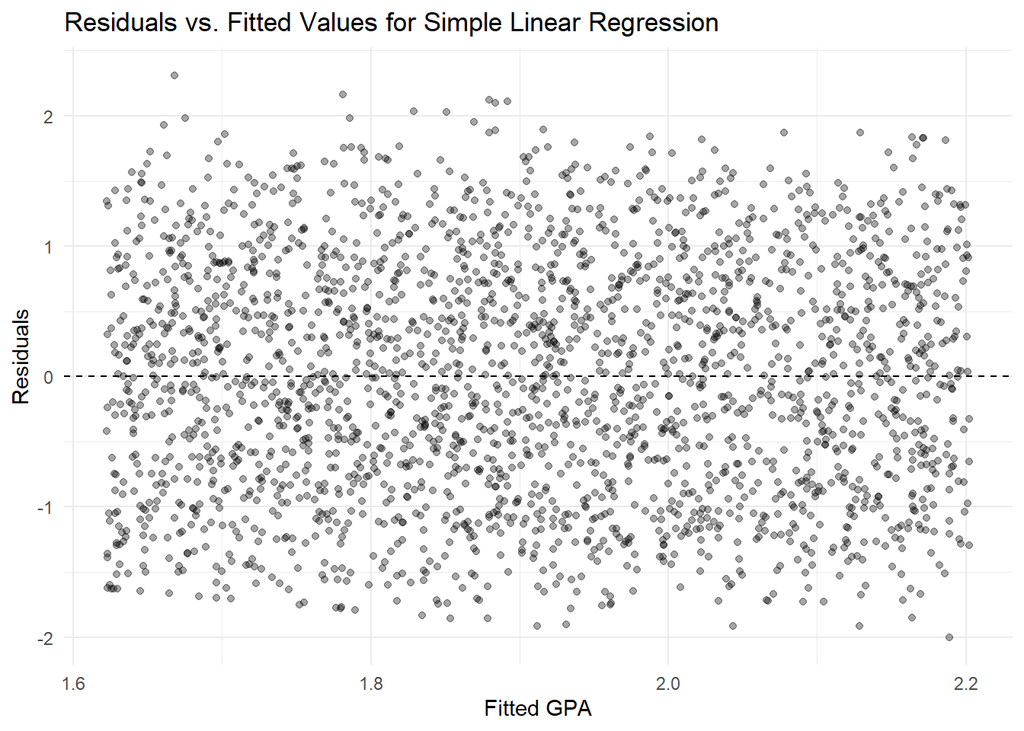

```r
analysis_data$residuals_simple <- resid(simple_model)
analysis_data$fitted_simple <- fitted(simple_model)

ggplot(analysis_data, aes(x = fitted_simple, y = residuals_simple)) +
  geom_point(alpha = 0.35) +
  geom_hline(yintercept = 0, linetype = "dashed") +
  labs(
    title = "Residuals vs. Fitted Values for Simple Linear Regression",
    x = "Fitted GPA",
    y = "Residuals"
  ) +
  theme_minimal()
```

For the linear regression model and the t-test on β1 to be valid, we assume:

- Linearity The relationship between weekly study time and GPA is approximately linear. Evidence: The scatterplot with a fitted regression line shows a slight upward trend with no strong curved pattern.
- Normality of errors The errors are normally distributed around 0. Evidence: The residuals from the fitted model are roughly symmetric around 0 with no extreme outliers (based on the residual plot and model summary).
- Constant variance The spread of the residuals is approximately constant across all values of weekly study time. Evidence: In the residual-vs-fitted plot (residuals vs StudyTimeWeekly), the points form a roughly horizontal band without a clear “fan” or funnel shape.
- Independence Each student in the dataset contributes one observation, and students are assumed to be independent of each other.

Given these conditions, the usual t-test for the slope in simple linear regression is appropriate.

## Hypotheses

We test whether increased weekly study time is associated with GPA: H0:β1=0(study time is not linearly related to GPA) HA:β1 is no 0(study time is associated with GPA)

## Test Statistic and Sample Size

The sample size n is obtained from the dataset:

which gives n=2392 students, so the regression has n−2 = 2390 degrees of freedom.

```r
n  <- nrow(analysis_data)
df <- n - 2
n
```

```
## [1] 2392
```

```r
df
```

```
## [1] 2390
```

This gives n = 2392 students, so the regression has n - 2 = 2390 degrees of freedom.

## P-value

```r
t_stat <- summary(simple_model)$coefficients["StudyTimeWeekly", "t value"]
t_stat
```

```
## [1] 8.908665
```

```r
p_value <- 2 * pt(-abs(t_stat), df = df)
p_value
```

```
## [1] 1.000201e-18
```

Under `H0`, this test statistic follows a t distribution with 2390 degrees of freedom. The corresponding two-sided p-value is extremely small.

## Results and Interpretation

Because the p-value for the slope is far smaller than α = 0.05, we reject the null hypothesis. There is strong statistical evidence that β1 is not 0; in other words, weekly study time is associated with GPA.

## Multiple Regression Extension

To deepen the analysis, we expand the model by adding variables that may also influence academic performance:

- Absences
- ParentalSupport
- Tutoring

This allows us to ask a more realistic question: Does weekly study time still predict GPA after accounting for attendance and support-related factors?

```r
multiple_model <- lm(GPA ~ StudyTimeWeekly + Absences + ParentalSupport + Tutoring,
                     data = analysis_data)
summary(multiple_model)
```

```
##
## Call:
## lm(formula = GPA ~ StudyTimeWeekly + Absences + ParentalSupport +
##     Tutoring, data = analysis_data)
##
## Residuals:
##      Min       1Q   Median       3Q      Max
## -0.92031 -0.16920 -0.00515  0.16545  0.83321
##
## Coefficients:
##                    Estimate Std. Error t value Pr(>|t|)
## (Intercept)       2.6625722  0.0207322  128.43   <2e-16 ***
## StudyTimeWeekly   0.0287671  0.0008728   32.96   <2e-16 ***
## Absences         -0.0993610  0.0005819 -170.74   <2e-16 ***
## ParentalSupport1  0.1714041  0.0198156    8.65   <2e-16 ***
## ParentalSupport2  0.3092159  0.0187659   16.48   <2e-16 ***
## ParentalSupport3  0.4634528  0.0188934   24.53   <2e-16 ***
## ParentalSupport4  0.6215607  0.0224096   27.74   <2e-16 ***
## TutoringYes       0.2508179  0.0107396   23.36   <2e-16 ***
## ---
## Signif. codes:  0 '***' 0.001 '**' 0.01 '*' 0.05 '.' 0.1 ' ' 1
##
## Residual standard error: 0.2409 on 2384 degrees of freedom
## Multiple R-squared:  0.9309, Adjusted R-squared:  0.9307
## F-statistic:  4590 on 7 and 2384 DF,  p-value: < 2.2e-16
```

## Comparing Model Fit

```r
model_comparison <- tibble(
  Model = c("Simple Linear Regression", "Multiple Regression"),
  R_squared = c(summary(simple_model)$r.squared,
                summary(multiple_model)$r.squared),
  Adjusted_R_squared = c(summary(simple_model)$adj.r.squared,
                         summary(multiple_model)$adj.r.squared),
)

model_comparison
```

```
## # A tibble: 2 × 3
##   Model                    R_squared Adjusted_R_squared
##   <chr>                        <dbl>              <dbl>
## 1 Simple Linear Regression    0.0321             0.0317
## 2 Multiple Regression         0.931              0.931
```

This comparison helps us evaluate whether the additional predictors explain more GPA variation than study time alone. In most educational settings, it is more realistic to expect student performance to depend on several related factors rather than one variable by itself.

# Discussion

## Interpretation of Results

Our analysis yields a striking contrast between statistical significance and practical impact. Statistically, we found overwhelming evidence of a positive linear relationship between study time and GPA. With a p-value of approximately $1.0 \times 10^{-18}$, we confidently reject the null hypothesis. The data clearly suggests that, in this population, students who study more generally achieve higher GPAs.

However, the practical significance of this finding is modest. Our estimated slope of $\hat{\beta}_1 \approx 0.029$ indicates that for every additional hour a student studies per week, their GPA is predicted to increase by only 0.03 points. To put this in perspective, a student would need to increase their weekly study time by approximately 34 hours to raise their GPA by a single point (e.g., from a 2.0 to a 3.0). This “effort cost” is realistically unfeasible for most high schoolers.

Furthermore, the coefficient of determination ($R^2$), calculated as the square of our correlation $r \approx 0.179$, is approximately 0.032. This means that weekly study time explains only 3.2% of the variation in students’ GPAs. The vast majority (96.8%) of the differences in academic performance are driven by unmodeled factors, such as prior knowledge, test-taking skills, or socioeconomic support.

The multiple regression model helps address this issue by incorporating `Absences`, `ParentalSupport`, and `Tutoring`. This expanded model is more realistic and better aligned with how academic performance works in practice. Rather than treating GPA as the product of study time alone, it recognizes that student success depends on both individual effort and external support systems.

## Limitations:

The most significant limitation of this study is the use of a synthetic dataset. While the data is mathematically robust and meets the assumptions of linearity and homoscedasticity (as seen in our residual plots), it likely represents an idealized version of reality. “Too Clean” Linearity: In the real world, the relationship between study time and grades is rarely perfectly linear. We would expect to see “diminishing returns”, where the first 5 hours of study have a huge impact, but the difference between studying 15 hours and 20 hours is negligible. Our current linear model does not capture this potential plateau effect.

# Conclusion

Overall, this project shows that weekly study time is positively associated with GPA among high school students, but the relationship is not strong enough to explain academic performance on its own. The simple linear regression answers our original question clearly, while the multiple regression model offers a more nuanced and realistic picture by incorporating attendance and support-related variables. In other words, studying more does appear to help, but academic success is shaped by much more than time alone.